# The_EC349_Final_Markdown

## Model Selection

```r
glimpse(final_tibble_LASSO)
```

```
## Rows: 230,072
## Columns: 33
## $ stars.x                 <dbl> 2, 4, 2, 4, 1, 4, 1, 5, 4, 5, 5, 3, 4, 5, 4, 3…
## $ useful.x                <int> 0, 1, 3, 0, 7, 0, 1, 0, 3, 1, 0, 0, 1, 0, 1, 0…
## $ funny.x                 <int> 1, 0, 0, 0, 6, 0, 0, 1, 1, 0, 0, 0, 0, 0, 0, 0…
## $ cool.x                  <int> 0, 1, 0, 0, 5, 0, 0, 0, 4, 0, 2, 0, 1, 0, 0, 0…
## $ date                    <dttm> 2010-05-03 04:07:13, 2015-02-03 22:41:30, 201…
## $ review_count.x          <int> 151, 25, 4, 2, 104, 27, 27, 327, 131, 27, 30, …
## $ yelping_since           <dttm> 2008-07-21 06:33:02, 2011-03-27 01:47:34, 201…
## $ useful.y                <int> 166, 12, 4, 0, 161, 7, 9, 481, 349, 22, 35, 0,…
## $ funny.y                 <int> 200, 5, 0, 0, 28, 0, 4, 73, 121, 1, 8, 0, 11, …
## $ cool.y                  <int> 106, 10, 0, 0, 93, 0, 3, 116, 197, 3, 13, 0, 4…
## $ fans                    <int> 11, 1, 0, 0, 11, 0, 0, 9, 25, 2, 1, 0, 3, 4, 1…
## $ average_stars           <dbl> 4.18, 4.31, 2.75, 4.50, 4.07, 3.41, 4.04, 3.69…
## $ compliment_hot          <int> 0, 0, 0, 0, 9, 0, 0, 4, 69, 0, 0, 0, 0, 8, 0, …
```

[output cut: 20 more lines]

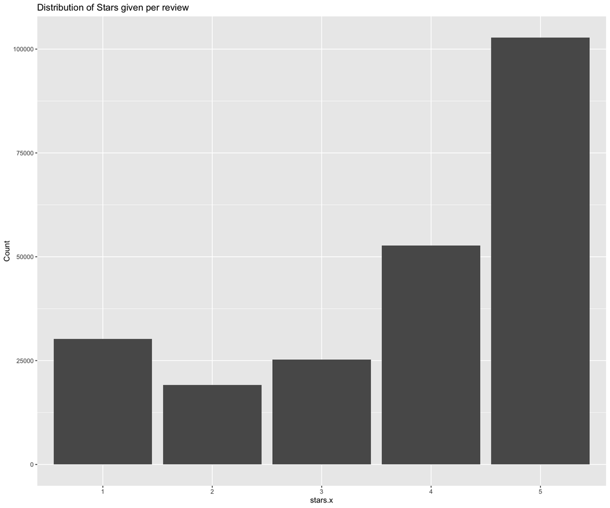

```r
# Distribution of Stars given per review

ggplot(final_tibble_LASSO, aes(x = as.factor(stars.x))) +
  geom_bar() +
  labs(title = "Distribution of Stars given per review", x = "stars.x", y = "Count")
```

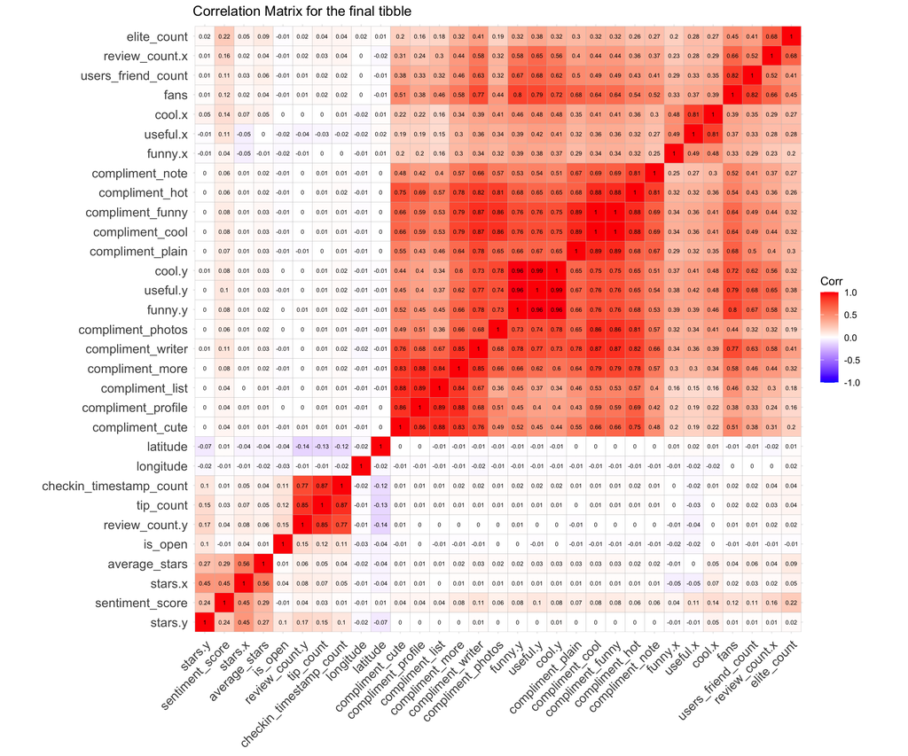

```r
# Correlation matrix for variables in the final tibble

numerical_vars <- sapply(final_tibble_LASSO, is.numeric)

cor_matrix <- cor(final_tibble_LASSO[, numerical_vars])

ggcorrplot(cor_matrix,
           type = "full",
           lab = TRUE,
           lab_size = 2,
           method = "square",
           colors = c("blue", "white", "red"),
           title = "Correlation Matrix for the final tibble",
           ggtheme = ggplot2::theme_minimal(),
           hc.order = TRUE,
           show.legend = TRUE)
```

As a consequence of the high number of feature variables within the data, the difficulty to distinguish between and make judgements on their potential impacts and the resultantly high risk of multi-collinearity (see matrix below, [5]), I opted to use the Least Absolute Shrinkage and Selection Operator (LASSO). In comparison to traditional OLS regression, the coefficients this model gives are biased towards 0, yet the variance of its predictions are greatly reduced. As a linear model though, it still maintains superior interpretability to other supervised learning methods that could be used to approach the problem. The LASSO regression enables us to interpret the direction of the effect of a variable, as opposed to solely its contribution to the predictive power of the model; an advantage of linear regression models. LASSO was preferred to Ridge regression for this application as it sets some of the coefficients to 0 (whereas Ridge purely shrinks them), potentially needed here to avoid multi-collinearity.

## Results and Evaluation

```r
# LASSO coefficients
print(coef(LASSO.mod))
```

```
## 33 x 1 sparse Matrix of class "dgCMatrix"
##                                    s0
## (Intercept)             -9.634851e-01
## useful.x                -1.077646e-01
## funny.x                 -3.228387e-02
## cool.x                   1.281473e-01
## date                    -1.967761e-10
## review_count.x           .
## yelping_since            4.456205e-11
## useful.y                 .
## funny.y                  5.488651e-06
## cool.y                   .
## fans                     .
## average_stars            7.059197e-01
## compliment_hot           .
## compliment_more          4.796229e-04
## compliment_profile       .
## compliment_cute          7.894915e-04
## compliment_list          .
## compliment_note          3.978160e-05
## compliment_plain         8.541200e-06
## compliment_cool          .
## compliment_funny         .
## compliment_writer       -3.784566e-04
## compliment_photos       -4.062075e-05
## latitude                -3.723899e-04
## longitude                6.823056e-04
## stars.y                  5.520831e-01
## review_count.y          -1.746900e-05
## is_open                  5.870197e-02
## tip_count                4.049917e-05
## checkin_timestamp_count  9.277512e-07
## elite_count             -2.385953e-02
## users_friend_count       1.950021e-05
## sentiment_score          8.342768e-02
```

```r
# LASSO Test Mean Squared Error
cat("LASSO MSE on Test Data:", LASSO_MSE, "\n")
```

```
## LASSO MSE on Test Data: 1.013915
```

```r
# LASSO Training Mean Squared Error
cat("LASSO MSE on Training Data:", LASSO_MSE_train, "\n")
```

```
## LASSO MSE on Training Data: 1.022067
```

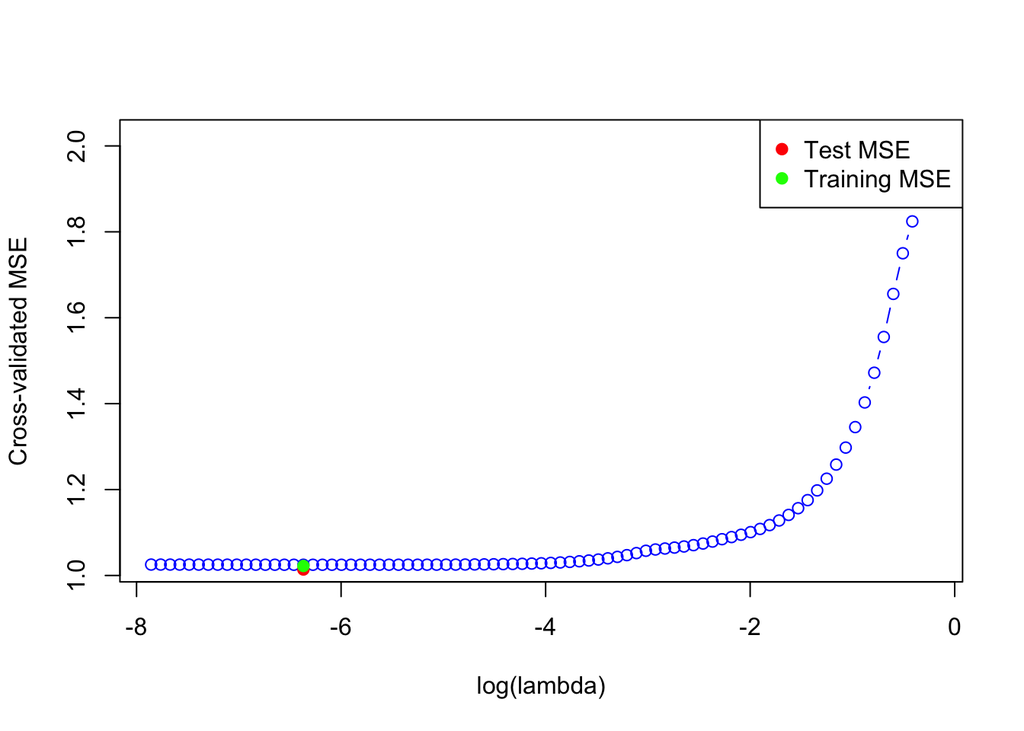

```r
# Visualisation for Training and Test MSE

plot(log(cv.out$lambda), cv.out$cvm, type = 'b', col = 'blue', xlab = 'log(lambda)', ylab = 'Cross-validated MSE')
points(log(lambda_LASSO_cv), LASSO_MSE, col = 'red', pch = 19)
points(log(lambda_LASSO_cv), LASSO_MSE_train, col = 'green', pch = 19)
legend("topright", legend = c("Test MSE", "Training MSE"), col = c("red", "green"), pch = 19)
```

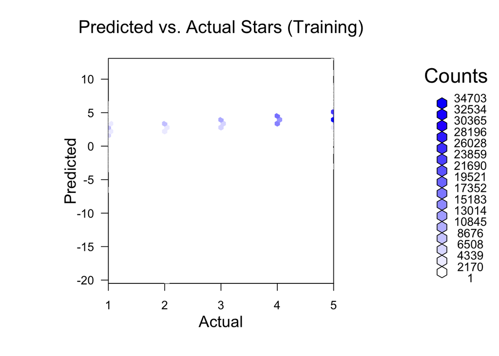

```r
# Plotting Predicted vs Actual values for the Test and Training data

y_axis_limits <- c(-5, 10)

hex_train <- hexbin(y_train_matrix, LASSO.pred_train, xbins = 50)
plot(hex_train, main = 'Predicted vs. Actual Stars (Training)', xlab = 'Actual', ylab = 'Predicted', colramp = function(n) colorRampPalette(c("white", "blue"))(n))
```

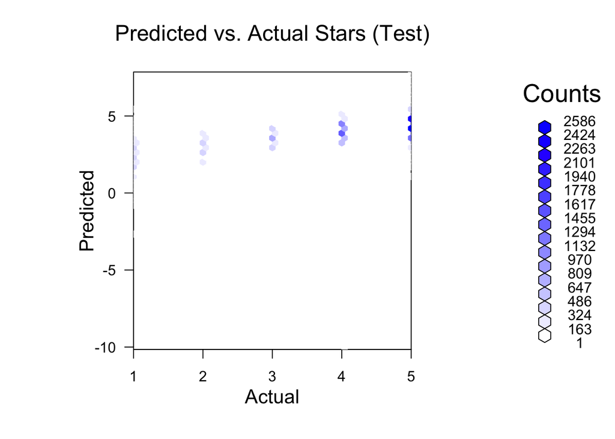

```r
hex_test <- hexbin(y_test_matrix, LASSO.pred, xbins = 50)
plot(hex_test, main = 'Predicted vs. Actual Stars (Test)', xlab = 'Actual', ylab = 'Predicted', colramp = function(n) colorRampPalette(c("white", "blue"))(n))
```

```r
summary(final_tibble_LASSO$stars.x)
```

```
##    Min. 1st Qu.  Median    Mean 3rd Qu.    Max.
##   1.000   3.000   4.000   3.776   5.000   5.000
```

The final MSE I managed to reach on the test data is 1.01, with a very similar 1.02 MSE for the training data. This may be a sign that the model is underfitting, and therefore not capturing enough of the key variation within the data to inform its predictions. In attempting to further reduce the MSE though, I could be limiting the model’s external validity by introducing features with too little variation within my dataset to be applicable on a wider scale, for example the attribute “BusinessAcceptsCreditCards”.

The largest positive coefficients in the model (indicating a positive relationship with “stars.x”) include those for the “sentiment_score” (the level of positivity conveyed within their review), “stars.y” (the average number of stars a business receives) and “average_stars” (the average number of stars a particular reviewer has given in the past). Significant negative relationships are also observed between “stars.x” and some of the features, including “useful.x” (the number of useful votes a review received) and “elite_count” (the number of years the reviewer has been an elite user).

As can be seen graphically below [6], the model also performs notably worse when attempting to predict reviews that are negative, showing a much wider variability in results. This may be partially due to the underlying distribution of the training and test data, both of which are dominated by positive reviews, and could therefore possibly be remedied with a larger training dataset. Though it may also be due to a general lack in complexity of the model, with not enough business attributes being included.

# My Greatest Challenge

My greatest challenge in completing this project turned was the variable selection problem. The balance between the sacrifice of information via removing observations to keep more explanatory variables and maintaining a larger dataset that contains fewer features was difficult to find, particularly when attempting to do so in a data driven manor. Ultimately, many of my decisions leant towards the second approach, in an effort to achieve a higher level of external validity. My choice of model partially reflects this challenge.

Additionally, I found the R code for conducting the sentiment analysis and creating some of the visualisations particularly challenging to operationalize. Though, given the intuitive importance of including a derivative of the main body of the reviews in the model, and the fact that including the sentiment analysis improved the performance of my model by reducing the test MSE my model was able to achieve by around 0.15, I see it as worthwhile. I believe that more detailed sentiment analysis, perhaps looking at emotions, could lead to further improvements in the model’s predictive ability.

# References

References

[1]: (2023) Yelp dataset. Available at: https://www.yelp.com/dataset/documentation/main (Accessed: 05 December 2023).

[2]: Data visualization with GGPLOT2 (2023) Data Analysis and Visualisation in R for Ecologists: Data visualization with ggplot2. Available at: https://datacarpentry.org/R-ecology-lesson/04-visualization-ggplot2.html (Accessed: 05 December 2023).

[3]: Be awesome in ggplot2: A practical guide to be highly effective - R software and Data Visualization (2020) STHDA. Available at: http://www.sthda.com/english/wiki/be-awesome-in-ggplot2-a-practical-guide-to-be-highly-effective-r-software-and-data-visualization?fbclid=IwAR3613N9JtkqxAKAu5TTl8JG4SX_vM4woddD1EO9gXSRUZ8yqIxfFMf5EIw (Accessed: 05 December 2023).

[4]: Robinson, J.S. and D. (2021) 2 sentiment analysis with Tidy Data: Text mining with R, A Tidy Approach. Available at: https://www.tidytextmining.com/sentiment (Accessed: 05 December 2023).

[5]: Visualization of a correlation matrix using GGPLOT2 in R (2021) GeeksforGeeks. Available at: https://www.geeksforgeeks.org/visualization-of-a-correlation-matrix-using-ggplot2-in-r/ (Accessed: 05 December 2023).

[6]: Wilke, C.O. (2020) Introduction to cowplot. Available at: https://cran.r-project.org/web/packages/cowplot/vignettes/introduction.html (Accessed: 05 December 2023).

# Tabula Statement

We’re part of an academic community at Warwick.

Whether studying, teaching, or researching, we’re all taking part in an expert conversation which must meet standards of academic integrity. When we all meet these standards, we can take pride in our own academic achievements, as individuals and as an academic community.

Academic integrity means committing to honesty in academic work, giving credit where we’ve used others’ ideas and being proud of our own achievements.

In submitting my work I confirm that:

1. I have read the guidance on academic integrity provided in the Student Handbook and understand the University regulations in relation to Academic Integrity. I am aware of the potential consequences of Academic Misconduct.
2. I declare that the work is all my own, except where I have stated otherwise.
3. No substantial part(s) of the work submitted here has also been submitted by me in other credit bearing assessments courses of study (other than in certain cases of a resubmission of a piece of work), and I acknowledge that if this has been done this may lead to an appropriate sanction.
4. Where a generative Artificial Intelligence such as ChatGPT has been used I confirm I have abided by both the University guidance and specific requirements as set out in the Student Handbook and the Assessment brief. I have clearly acknowledged the use of any generative Artificial Intelligence in my submission, my reasoning for using it and which generative AI (or AIs) I have used. Except where indicated the work is otherwise entirely my own.
5. I understand that should this piece of work raise concerns requiring investigation in relation to any of points above, it is possible that other work I have submitted for assessment will be checked, even if marks (provisional or confirmed) have been published.
6. Where a proof-reader, paid or unpaid was used, I confirm that the proofreader was made aware of and has complied with the University’s proofreading policy.
7. I consent that my work may be submitted to Turnitin or other analytical technology. I understand the use of this service (or similar), along with other methods of maintaining the integrity of the academic process, will help the University uphold academic standards and assessment fairness.

Privacy statement

The data on this form relates to your submission of coursework. The date and time of your submission, your identity, and the work you have submitted will be stored. We will only use this data to administer and record your coursework submission.